# Ulithi23 *Acropora* Metabolomics Analysis Workflow

Gabby Panayotakis

2025-01-06

## Metabolomics data cleaning and preparation workflow

### Goal:

To prepare and quality check raw metabolomic data prior to downstream metabolomics analyses (e.g. WGCNA, differential abundance analysis, etc…)

### About:

This workflow uses the “MetCleaning” R package to clean up and prepare MS peak spectra data prior to statistical analysis. Please refer to the [manual](https://github.com/MetabLAB/MetCleaning/blob/master/vignettes/MetCleaning.pdf) for further information. This workflow assumes that you are starting with a table of unannotated compounds and their MS peak intensities. Based off of the TidyMass tutorial [(here)](https://www.tidymass.org/docs/chapter2/1-create_mass_dataset/).

### **This workflow:**

1. Workspace Preparation
2. Data reading and preparation
3. Explore dataset
4. Data cleaning
5. Technical variable correction
6. Save the cleaned data

[figure not shown]

[Note: An important decision point in this script, is whether to keep or remove outliers (4. Data cleaning: Identify and remove outliers). Be sure to check results before moving to the next step.]{underline}

## Workspace Preparation

### Install and Load Packages

For more information, see “Chapter 1 Installation” from the Tidymass online tutorial.

This workflow utilizes the TidyMass package which includes tidyR and ggplot as dependencies. The following code will install TidyMass and all required dependencies. For further directions and troubleshooting see https://www.tidymass.org/docs/chapter1/1-installation/

```r
# install.packages("BiocManager")
# BiocManager::install("MSnbase")
#  if(!require(remotes)){
#      install.packages("remotes")
#  }
#  remotes::install_gitlab("tidymass/tidymass")
```

Clear environment and load package(s)

```r
rm(list = ls()) #clear environment
library(tidymass)
library(BiocManager)
```

```r
library(readr)
library(dplyr)
library(ggplotify)
library(hexbin)
library(readr)
```

### Input Files Preparation

For more information, see “Chapter 2 massDataset package” from the Tidymass online tutorial.

## Data reading and preparation

### Prepare the CSV files

This workflow requires three files for each ionization mode: (1) sample_info: a LCMS run metadata table (2) variable_info: a sample metadata table to be extracted from expression_data, and (3) expression_data: an ionization peaks table. We are also including (4) sample_groups for additional analysis including all metadata. Parameters for each file type are detailed below.

Note that your sample IDs must match exactly across all files and sample_info must match the compound ID in the associated expression data table.

**sample_info:** The columns `sample_id` (sample ID), `injection.order` (injection order of samples), `class` (Blank, QC, Subject, etc), and `batch` (batch number) are required.

**variable_info:** The columns `variable_id` (variable ID), `mz` (mass to charge ratio), `rt` (retention time, units are in seconds) are required.

**expression_data:** The columns `variable_id` (compound ID), `mz` (mass to charge ratio), `rt` (retention time, units are in seconds), and your expression data (where column names are your sample IDs) are required. Other compound information (e.g. isotope distribution) may also be included, but is not required.

**sample_groups:** The columns `sample_id` (sample ID) and `group` (control, treatment1, treatment2, etc) are required.

### Load Prepared CSV Files & Extract Datasets

Path to input files

```r
in_path <- "3-Metabolomic_workflow/2-Acropora/1-Input"
```

```r
peak_table_pos = read_csv(file.path(in_path, "1-Positive_ionization/U23_tidymass_acrop_pos_expression_data_normalized.csv"))
peak_table_neg = read_csv(file.path(in_path, "2-Negative_ionization/U23_tidymass_acrop_neg_expression_data_normalized.csv"))
sample_info_pos = read_csv(file.path(in_path, "1-Positive_ionization/U23_tidymass_acrop_pos_sample_info.csv"))
sample_info_neg = read_csv(file.path(in_path, "2-Negative_ionization/U23_tidymass_acrop_neg_sample_info.csv"))
sample_groups_pos = read_csv(file.path(in_path, "1-Positive_ionization/U23_tidymass_acrop_pos_sample_groups.csv"))
sample_groups_neg = read_csv(file.path(in_path, "2-Negative_ionization/U23_tidymass_acrop_neg_sample_groups.csv"))
#Add sample group information to sample info
sample_info_pos <- left_join(sample_info_pos, sample_groups_pos, by="sample_id")
sample_info_neg <- left_join(sample_info_neg, sample_groups_neg, by="sample_id")
```

Variable (metabolite) information (e.g. mass-to-charge ration (“mz”), retention time (“rt), isotope distribution (”isotope.dist”)) and expression data are in the peak tables, so we have to separate them

Positive

```r
expression_data_pos  <-
  peak_table_pos %>%
  dplyr::select(-c(variable_id:isotope.dist)) %>% #minus bc want all other cols
  as.data.frame() ; head(expression_data_pos)
```

```
##           M62          M61         M63          M64      M65         A306
## 1 8239.613300 1.916142e+04 8958.047123 1.952774e+04 2771.403 101534.13950
## 2    5.721673 7.815360e-02    7.160288 4.598153e-02    0.000     18.14892
## 3    0.000000 6.186312e+02    0.000000 0.000000e+00    0.000      0.00000
## 4 4008.259929 9.899216e+03 4232.411617 9.992084e+03 1251.282  56637.36993
## 5    0.000000 0.000000e+00    0.000000 0.000000e+00    0.000      0.00000
## 6 1427.790430 5.103777e+03 1507.430184 5.123721e+03    0.000  35022.92785
##           A309        A325      A328        A331         A339        A323
## 1 4.634900e+04 44369.43845 18115.712 325.8150864 64113.835720 8481.817684
## 2 5.614882e-01    23.07232     0.000   0.3858858     1.841263    4.130493
## 3 0.000000e+00     0.00000     0.000   0.0000000     0.000000    0.000000
## 4 2.588220e+04 24806.80172  9014.455 113.7030250 35810.779560 4189.257414
## 5 0.000000e+00     0.00000     0.000   9.5052006     0.000000    0.000000
## 6 1.518855e+04 14883.21222  4176.100   0.0000000 22484.625910 1379.076824
##           A326         A340      A315          A21         A22          A23
## 1 11388.243750 8.872738e+03 5329.0722 47268.188220 75334.78672 28512.510180
## 2     8.482701 4.095808e-02    0.0000     5.888792    25.04432     4.226837
## 3     0.000000 0.000000e+00    0.0000     0.000000     0.00000     0.000000
## 4  5539.611437 4.318933e+03 2592.6319 26423.199060 41892.56556 15316.315430
## 5     0.000000 0.000000e+00    0.0000     0.000000   163.98320   110.955329
## 6  2664.507106 1.467413e+03  467.0993 16038.649720 24786.02618  8676.691704
##           A25         A26          A24
## 1 71733.00674 49170.57890 17037.268720
## 2    19.79799    14.80845     3.387577
## 3     0.00000     0.00000     0.000000
## 4 40307.87141 26857.90479  8615.878492
## 5     0.00000     0.00000     0.000000
## 6 23937.37603 15242.13815  4205.555101
```

```r
variable_info_pos =
  peak_table_pos %>%
  dplyr::select(variable_id:isotope.dist) %>%
  as.data.frame(); head(variable_info_pos)
```

```
##        variable_id       mz       rt                           isotope.dist
## 1 5.78_245.2732m/z 245.2732 5.782317                      100 - 45.6 - 3.82
## 2 3.12_627.3635m/z 627.3635 3.122200       100 - 39.5 - 9.45 - 2.44 - 0.405
## 3 3.78_996.1757m/z 996.1757 3.776400 97.3 - 100 - 56.7 - 22.5 - 4.46 - 0.17
## 4 5.78_245.3412m/z 245.3412 5.782317                             100 - 29.2
## 5   3.78_117.2729n 118.2802 3.783550                                    100
## 6 5.78_245.3927m/z 245.3927 5.782317                            100 - 0.798
```

```r
rownames(expression_data_pos) <-  variable_info_pos$variable_id; head(expression_data_pos)
```

```
##                          M62          M61         M63          M64      M65
## 5.78_245.2732m/z 8239.613300 1.916142e+04 8958.047123 1.952774e+04 2771.403
## 3.12_627.3635m/z    5.721673 7.815360e-02    7.160288 4.598153e-02    0.000
## 3.78_996.1757m/z    0.000000 6.186312e+02    0.000000 0.000000e+00    0.000
## 5.78_245.3412m/z 4008.259929 9.899216e+03 4232.411617 9.992084e+03 1251.282
## 3.78_117.2729n      0.000000 0.000000e+00    0.000000 0.000000e+00    0.000
## 5.78_245.3927m/z 1427.790430 5.103777e+03 1507.430184 5.123721e+03    0.000
##                          A306         A309        A325      A328        A331
## 5.78_245.2732m/z 101534.13950 4.634900e+04 44369.43845 18115.712 325.8150864
## 3.12_627.3635m/z     18.14892 5.614882e-01    23.07232     0.000   0.3858858
## 3.78_996.1757m/z      0.00000 0.000000e+00     0.00000     0.000   0.0000000
## 5.78_245.3412m/z  56637.36993 2.588220e+04 24806.80172  9014.455 113.7030250
## 3.78_117.2729n        0.00000 0.000000e+00     0.00000     0.000   9.5052006
## 5.78_245.3927m/z  35022.92785 1.518855e+04 14883.21222  4176.100   0.0000000
##                          A339        A323         A326         A340      A315
## 5.78_245.2732m/z 64113.835720 8481.817684 11388.243750 8.872738e+03 5329.0722
## 3.12_627.3635m/z     1.841263    4.130493     8.482701 4.095808e-02    0.0000
## 3.78_996.1757m/z     0.000000    0.000000     0.000000 0.000000e+00    0.0000
## 5.78_245.3412m/z 35810.779560 4189.257414  5539.611437 4.318933e+03 2592.6319
## 3.78_117.2729n       0.000000    0.000000     0.000000 0.000000e+00    0.0000
## 5.78_245.3927m/z 22484.625910 1379.076824  2664.507106 1.467413e+03  467.0993
##                           A21         A22          A23         A25         A26
## 5.78_245.2732m/z 47268.188220 75334.78672 28512.510180 71733.00674 49170.57890
## 3.12_627.3635m/z     5.888792    25.04432     4.226837    19.79799    14.80845
## 3.78_996.1757m/z     0.000000     0.00000     0.000000     0.00000     0.00000
## 5.78_245.3412m/z 26423.199060 41892.56556 15316.315430 40307.87141 26857.90479
## 3.78_117.2729n       0.000000   163.98320   110.955329     0.00000     0.00000
## 5.78_245.3927m/z 16038.649720 24786.02618  8676.691704 23937.37603 15242.13815
##                           A24
## 5.78_245.2732m/z 17037.268720
## 3.12_627.3635m/z     3.387577
## 3.78_996.1757m/z     0.000000
## 5.78_245.3412m/z  8615.878492
## 3.78_117.2729n       0.000000
## 5.78_245.3927m/z  4205.555101
```

```r
expression_data_pos[expression_data_pos == 0] <- NA #NA is missing data
#rows are metabolite names, columns are sample name
```

Negative

```r
expression_data_neg  <-
  peak_table_neg %>%
  dplyr::select(-c(variable_id:isotope.dist)) %>%
  as.data.frame() ; head(expression_data_neg)
```

```
##   M62 M61 M63 M64 M65 A306 A309 A325 A328 A331 A339 A323 A326 A340 A315 A21 A22
## 1   0   0   0   0   0    0    0    0    0    0    0    0    0    0    0   0   0
## 2   0   0   0   0   0    0    0    0    0    0    0    0    0    0    0   0   0
## 3   0   0   0   0   0    0    0    0    0    0    0    0    0    0    0   0   0
## 4   0   0   0   0   0    0    0    0    0    0    0    0    0    0    0   0   0
## 5   0   0   0   0   0    0    0    0    0    0    0    0    0    0    0   0   0
## 6   0   0   0   0   0    0    0    0    0    0    0    0    0    0    0   0   0
##   A23 A25 A26 A24
## 1   0   0   0   0
## 2   0   0   0   0
## 3   0   0   0   0
## 4   0   0   0   0
## 5   0   0   0   0
## 6   0   0   0   0
```

```r
variable_info_neg =
  peak_table_neg %>%
  dplyr::select(variable_id:isotope.dist) %>%
  as.data.frame(); head(variable_info_neg)
```

```
##        variable_id       mz       rt isotope.dist
## 1 1.16_235.2884m/z 235.2884 1.158717   100 - 47.8
## 2 1.16_235.3573m/z 235.3573 1.158717   100 - 30.8
## 3 1.16_235.4103m/z 235.4103 1.158717          100
## 4 1.16_233.2722m/z 233.2722 1.158717   100 - 44.5
## 5 1.16_235.4975m/z 235.4975 1.158717          100
## 6 1.16_233.3403m/z 233.3403 1.158717   100 - 17.3
```

```r
rownames(expression_data_neg) <-  variable_info_neg$variable_id; head(expression_data_neg)
```

```
##                  M62 M61 M63 M64 M65 A306 A309 A325 A328 A331 A339 A323 A326
## 1.16_235.2884m/z   0   0   0   0   0    0    0    0    0    0    0    0    0
## 1.16_235.3573m/z   0   0   0   0   0    0    0    0    0    0    0    0    0
## 1.16_235.4103m/z   0   0   0   0   0    0    0    0    0    0    0    0    0
## 1.16_233.2722m/z   0   0   0   0   0    0    0    0    0    0    0    0    0
## 1.16_235.4975m/z   0   0   0   0   0    0    0    0    0    0    0    0    0
## 1.16_233.3403m/z   0   0   0   0   0    0    0    0    0    0    0    0    0
##                  A340 A315 A21 A22 A23 A25 A26 A24
## 1.16_235.2884m/z    0    0   0   0   0   0   0   0
## 1.16_235.3573m/z    0    0   0   0   0   0   0   0
## 1.16_235.4103m/z    0    0   0   0   0   0   0   0
## 1.16_233.2722m/z    0    0   0   0   0   0   0   0
## 1.16_235.4975m/z    0    0   0   0   0   0   0   0
## 1.16_233.3403m/z    0    0   0   0   0   0   0   0
```

```r
expression_data_neg[expression_data_neg == 0] <- NA
```

Make sure that rowname and colname orders match up. If output is false, then cols dont match row names (could be extra col, etc). Check where and remove from the CSV files

```r
expression_data_pos =
  expression_data_pos[,sample_info_pos$sample_id]
all(diff(match(colnames(expression_data_pos),sample_info_pos$sample_id)) > 0)
```

```
## [1] TRUE
```

```r
expression_data_neg =
  expression_data_neg[,sample_info_neg$sample_id]
all(diff(match(colnames(expression_data_neg),sample_info_neg$sample_id)) > 0)
```

```
## [1] TRUE
```

Verify the dataset qualities

```r
ncol(expression_data_pos)
```

```
## [1] 21
```

```r
length(sample_groups_pos$sample_id)
```

```
## [1] 21
```

```r
setdiff(colnames(expression_data_pos), sample_groups_pos$sample_id)
```

```
## character(0)
```

```r
ncol(expression_data_neg)
```

```
## [1] 21
```

```r
length(sample_groups_neg$sample_id)
```

```
## [1] 21
```

```r
setdiff(colnames(expression_data_neg), sample_groups_neg$sample_id)
```

```
## character(0)
```

### Create mass_data class object for each ionization mode

```r
object_pos <-
  create_mass_dataset(
    expression_data = expression_data_pos,
    sample_info = sample_info_pos,
    variable_info = variable_info_pos
  )
object_pos
```

```
## --------------------
## massdataset version: 0.99.0
## --------------------
## 1.expression_data:[ 8623 x 21 data.frame]
## 2.sample_info:[ 21 x 6 data.frame]
## 21 samples:A21 A22 A23 ... M64 M65
## 3.variable_info:[ 8623 x 4 data.frame]
## 8623 variables:5.78_245.2732m/z 3.12_627.3635m/z 3.78_996.1757m/z ... 3.02_297.9912m/z 13.25_556.2761m/z
## 4.sample_info_note:[ 6 x 2 data.frame]
## 5.variable_info_note:[ 4 x 2 data.frame]
## 6.ms2_data:[ 0 variables x 0 MS2 spectra]
## --------------------
## Processing information
## 1 processings in total
## create_mass_dataset ----------
##       Package         Function.used                Time
## 1 massdataset create_mass_dataset() 2026-05-28 09:19:10
```

```r
object_neg <-
  create_mass_dataset(
    expression_data = expression_data_neg,
    sample_info = sample_info_neg,
    variable_info = variable_info_neg
  )
object_neg
```

```
## --------------------
## massdataset version: 0.99.0
## --------------------
## 1.expression_data:[ 4310 x 21 data.frame]
## 2.sample_info:[ 21 x 6 data.frame]
## 21 samples:A21 A22 A23 ... M64 M65
## 3.variable_info:[ 4310 x 4 data.frame]
## 4310 variables:1.16_235.2884m/z 1.16_235.3573m/z 1.16_235.4103m/z ... 4.07_238.9111m/z 4.07_122.9692m/z
## 4.sample_info_note:[ 6 x 2 data.frame]
## 5.variable_info_note:[ 4 x 2 data.frame]
## 6.ms2_data:[ 0 variables x 0 MS2 spectra]
## --------------------
## Processing information
## 1 processings in total
## create_mass_dataset ----------
##       Package         Function.used                Time
## 1 massdataset create_mass_dataset() 2026-05-28 09:19:10
```

Potential save/export option if not continuing analysis in same script.

```r
# save(object_pos, file = "feature_table/object_pos")
# save(object_neg, file = "feature_table/object_neg")
#
# export_mass_dataset(object = object_pos,
#                     file_type = "xlsx",
#                     path = "feature_table/demo_data_pos")
# export_mass_dataset(object = object_neg,
#                     file_type = "xlsx",
#                     path = "feature_table/demo_data_neg")
```

We will skip Chapters 3 & 4 of the Tidymass online tutorial, because we do not need to process raw peak data.

## Explore dataset

For more information, see “Chapter 5 Explore data” from the Tidymass online tutorial.

### Positive Mode

Assess that the loaded data is correct

```r
dim(object_pos)
```

```
## variables   samples
##      8623        21
```

```r
object_pos %>%
  activate_mass_dataset(what = "sample_info") %>%
  dplyr::count(class)
```

```
##     class  n
## 1 Subject 21
```

```r
object_pos %>%
  activate_mass_dataset(what = "sample_info") %>%
  dplyr::count(group)
```

```
##      group  n
## 1 Acropora 21
```

```r
object_pos %>%
  activate_mass_dataset(what = "sample_info") %>%
  dplyr::count(batch)
```

```
##   batch  n
## 1     3 21
```

Generate a peak distribution plot

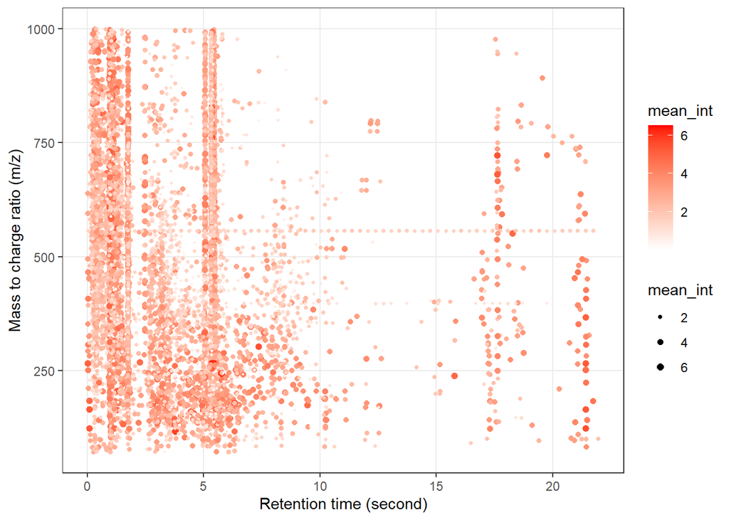

```r
object_pos %>%
  `+`(1) %>%
  log(10) %>%
  show_mz_rt_plot() +
  scale_size_continuous(range = c(0.01, 2))
```

Explore missing values

```r
get_mv_number(object = object_pos)
```

```
## [1] 68483
```

```r
get_mv_number(object = object_pos, by = "sample") %>% #per sample
  head()
```

```
##  A21  A22  A23  A24  A25  A26
## 3043 2987 3168 3399 3048 2824
```

```r
get_mv_number(object = object_pos, by = "variable") %>% #per variable
  head()
```

```
## 5.78_245.2732m/z 3.12_627.3635m/z 3.78_996.1757m/z 5.78_245.3412m/z
##                0                3               20                0
##   3.78_117.2729n 5.78_245.3927m/z
##               18                2
```

Plot the MV data

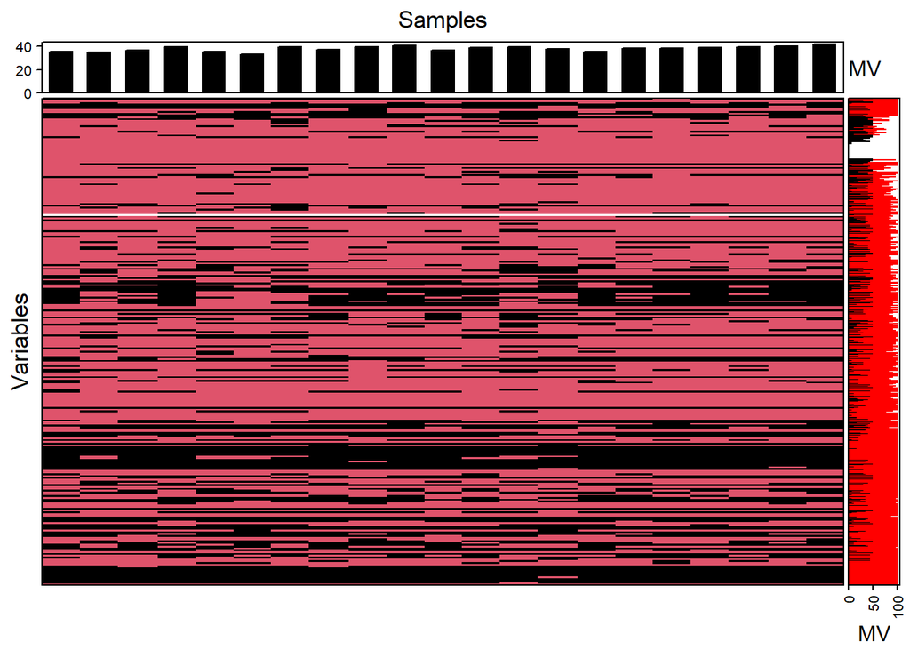

```r
show_missing_values(object = object_pos, show_column_names = FALSE, percentage = TRUE)
```

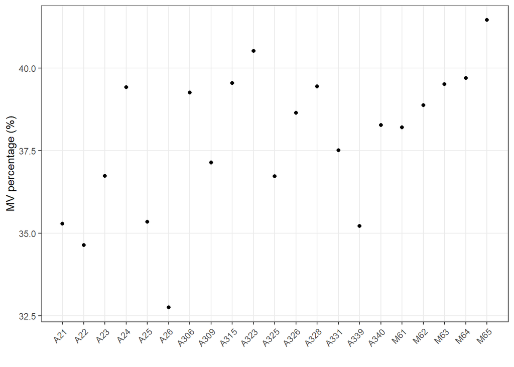

```r
show_sample_missing_values(object = object_pos, percentage = TRUE)
```

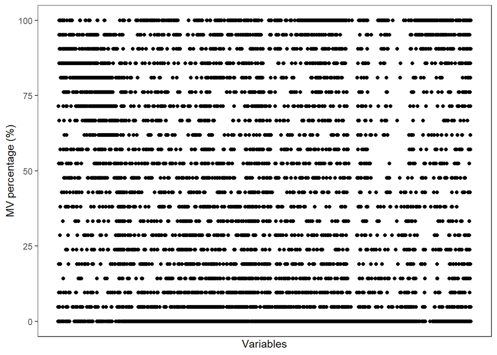

```r
show_variable_missing_values(
  object = object_pos,
  percentage = TRUE,
  show_x_text = FALSE,
  show_x_ticks = FALSE
) +
  scale_size_continuous(range = c(0.01, 1))
```

Repeat for Negative mode.

### Negative Mode

Assess that the loaded data is correct

```r
dim(object_neg)
```

```
## variables   samples
##      4310        21
```

```r
object_neg %>%
  activate_mass_dataset(what = "sample_info") %>%
  dplyr::count(class)
```

```
##     class  n
## 1 Subject 21
```

```r
object_neg %>%
  activate_mass_dataset(what = "sample_info") %>%
  dplyr::count(group)
```

```
##      group  n
## 1 Acropora 21
```

```r
object_neg %>%
  activate_mass_dataset(what = "sample_info") %>%
  dplyr::count(batch)
```

```
##   batch  n
## 1     4 21
```

Generate a peak distribution plot

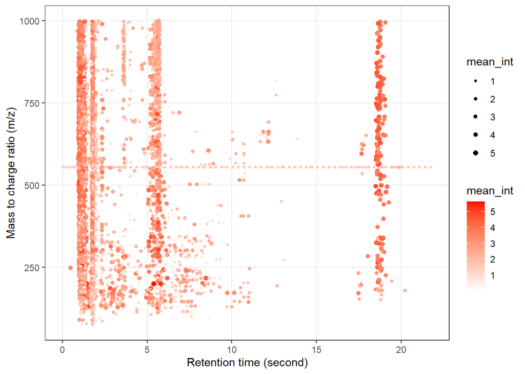

```r
object_neg %>%
  `+`(1) %>%
  log(10) %>%
  show_mz_rt_plot() +
  scale_size_continuous(range = c(0.01, 2))
```

Explore missing values

```r
get_mv_number(object = object_neg)
```

```
## [1] 24978
```

```r
get_mv_number(object = object_neg, by = "sample") %>% #per sample
  head()
```

```
##  A21  A22  A23  A24  A25  A26
## 1049 1069 1092 1326 1016 1070
```

```r
get_mv_number(object = object_neg, by = "variable") %>% #per variable
  head()
```

```
## 1.16_235.2884m/z 1.16_235.3573m/z 1.16_235.4103m/z 1.16_233.2722m/z
##               21               21               21               21
## 1.16_235.4975m/z 1.16_233.3403m/z
##               21               21
```

Plot the MV data

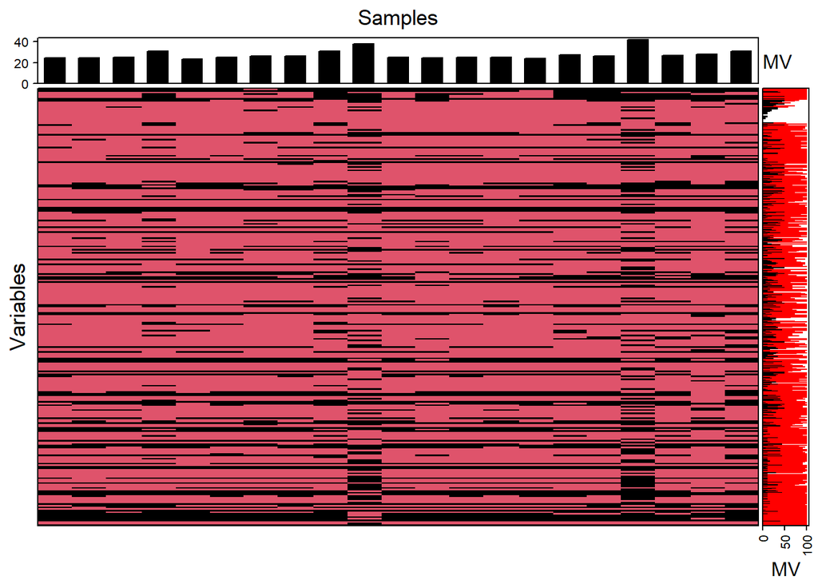

```r
show_missing_values(object = object_neg, show_column_names = FALSE, percentage = TRUE)
```

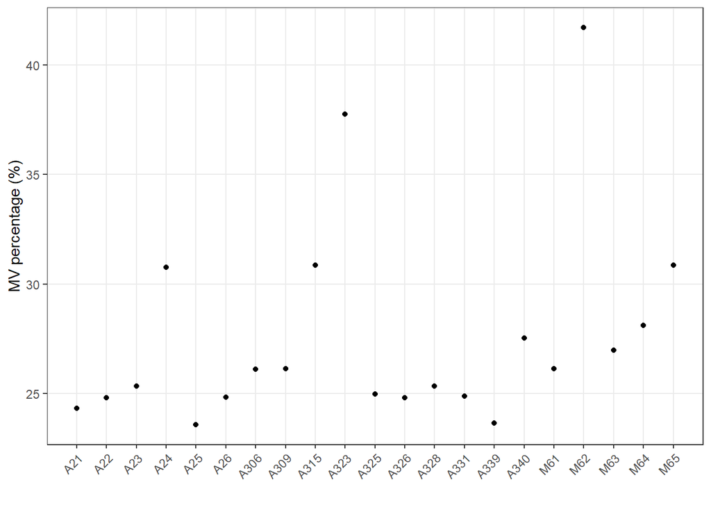

```r
show_sample_missing_values(object = object_neg, percentage = TRUE)
```

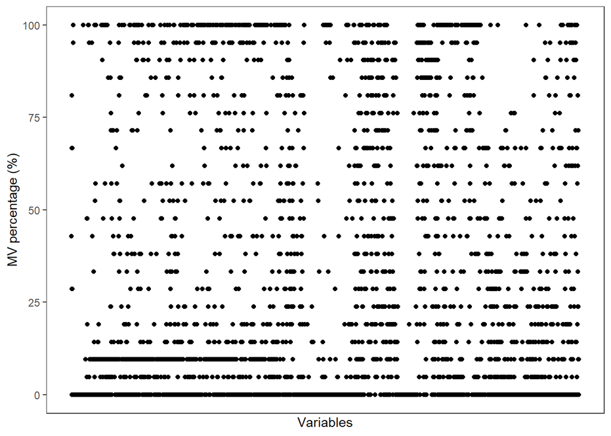

```r
show_variable_missing_values(
  object = object_neg,
  percentage = TRUE,
  show_x_text = FALSE,
  show_x_ticks = FALSE
) +
  scale_size_continuous(range = c(0.01, 1))
```

## Data cleaning

For more information, see “Chapter 6 Data cleaning” from the Tidymass online tutorial.

Change batch to character.

```r
object_pos <-
  object_pos %>%
  activate_mass_dataset(what = "sample_info") %>%
  dplyr::mutate(batch = as.character(batch))

object_neg <-
  object_neg %>%
  activate_mass_dataset(what = "sample_info") %>%
  dplyr::mutate(batch = as.character(batch))
```

### Pre-cleaning report

Create a report of raw data quality. Save as HTML. It is recommended to review the HTML report for the pre-cleaned dataset before moving forward.

```r
# object_pos@sample_info$class <- gsub("Sample", "Subject", object_pos@sample_info$class)
# massqc::massqc_report(object = object_pos,
#                       path = "3-Metabolomic_workflow/2-Acropora/3-Output/Pos_data_quality_pre_cleanup")
# object_neg@sample_info$class <- gsub("Sample", "Subject", object_neg@sample_info$class)
# massqc::massqc_report(object = object_neg,
#                       path = "3-Metabolomic_workflow/2-Acropora/3-Output/Neg_data_quality_pre_cleanup")
```

### Filter out noisy metabolites

**Note:** While the ‘80% rule’ is the standard for the metabolomics field, you should consider whether is makes sense for your experimental design, assess how it impacts your data, and apply a different filtering threshold, if necessary

#### Positive

Check MVpercentage before noisy feature removal

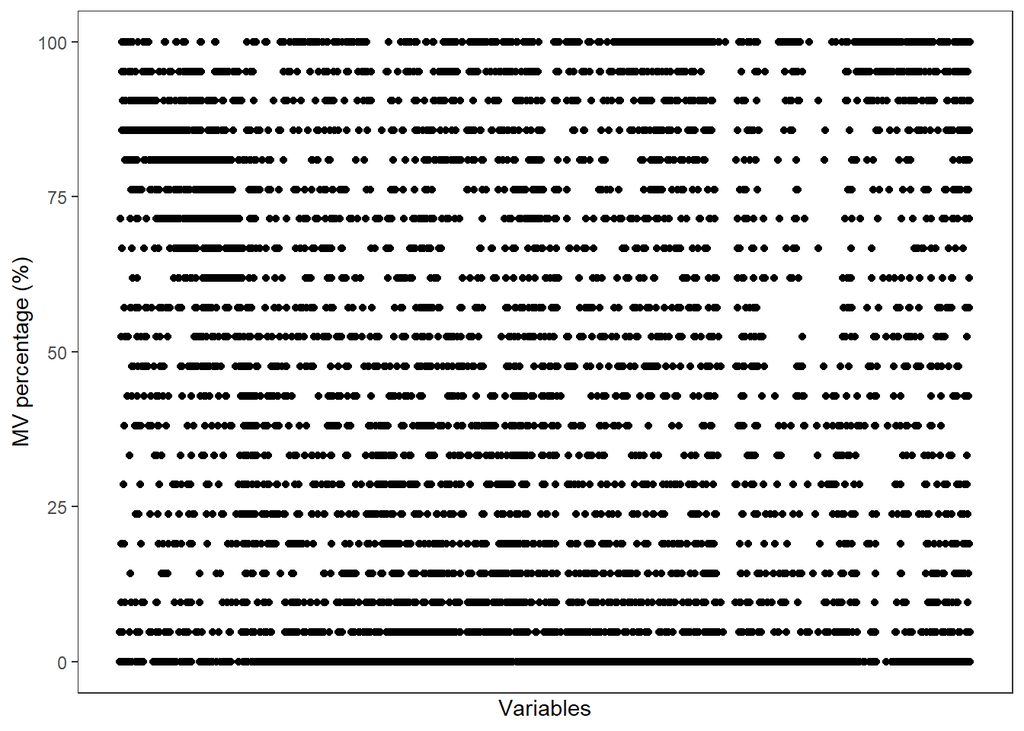

```r
show_variable_missing_values(object = object_pos %>%
                               activate_mass_dataset(what = "sample_info"),
                             percentage = TRUE) +
  scale_size_continuous(range = c(0.01, 2))
```

```r
MV.lim = 0.4 #standard missing value threshold for Acropora

nfeatures_before <- nrow(extract_variable_info(object_pos))

object_pos =
  object_pos %>%
  mutate_variable_na_freq()

object_pos <-
  object_pos %>%
  activate_mass_dataset(what = "variable_info") %>%
  filter(na_freq < MV.lim)

nfeatures_after <- nrow(extract_variable_info(object_pos))
```

Check the before and after to verify and quantify MVs removed

```r
#Check before and after
nfeatures_before
```

```
## [1] 8623
```

```r
nfeatures_after
```

```
## [1] 4959
```

```r
nfeatures_before - nfeatures_after #total MVs removed
```

```
## [1] 3664
```

Check MVpercentage after noisy feature removal

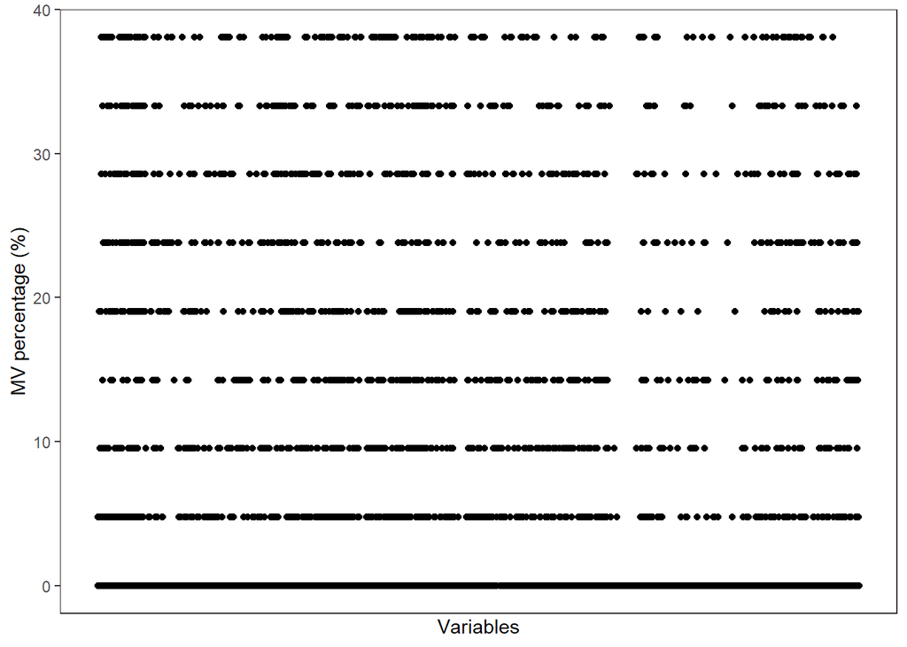

```r
show_variable_missing_values(object = object_pos %>%
                               activate_mass_dataset(what = "sample_info"),
                             percentage = TRUE) +
  scale_size_continuous(range = c(0.01, 2))
```

#### Negative

Check MVpercentage before noisy feature removal

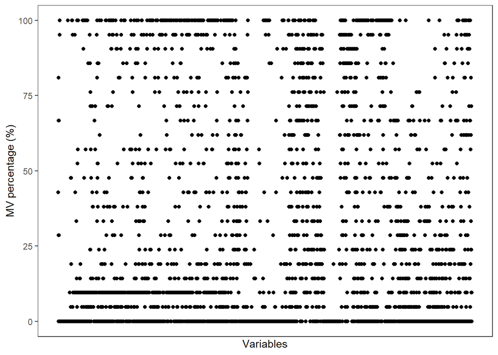

```r
show_variable_missing_values(object = object_neg %>%
                               activate_mass_dataset(what = "sample_info"),
                             percentage = TRUE) +
  scale_size_continuous(range = c(0.01, 2))
```

```r
MV.lim = 0.4 #standard missing value threshold for Acropora

nfeatures_before <- nrow(extract_variable_info(object_neg))

object_neg =
  object_neg %>%
  mutate_variable_na_freq()

object_neg <-
  object_neg %>%
  activate_mass_dataset(what = "variable_info") %>%
  filter(na_freq < MV.lim)

nfeatures_after <- nrow(extract_variable_info(object_neg))
```

Check the before and after to verify and quantify MVs removed

```r
#Check before and after
nfeatures_before
```

```
## [1] 4310
```

```r
nfeatures_after
```

```
## [1] 3097
```

```r
nfeatures_before - nfeatures_after #total MVs removed
```

```
## [1] 1213
```

Check MVpercentage after noisy feature removal

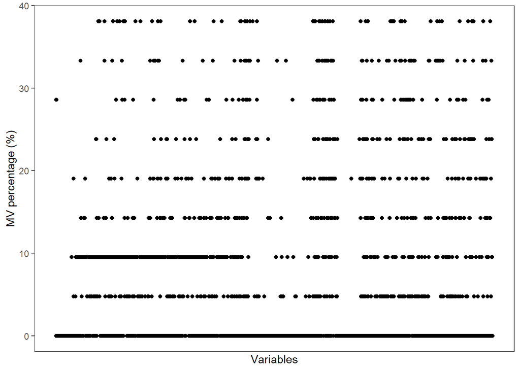

```r
show_variable_missing_values(object = object_neg %>%
                               activate_mass_dataset(what = "sample_info"),
                             percentage = TRUE) +
  scale_size_continuous(range = c(0.01, 2))
```

### Identify and remove outlier samples

Outlier detection

Visualize the samples

Positive

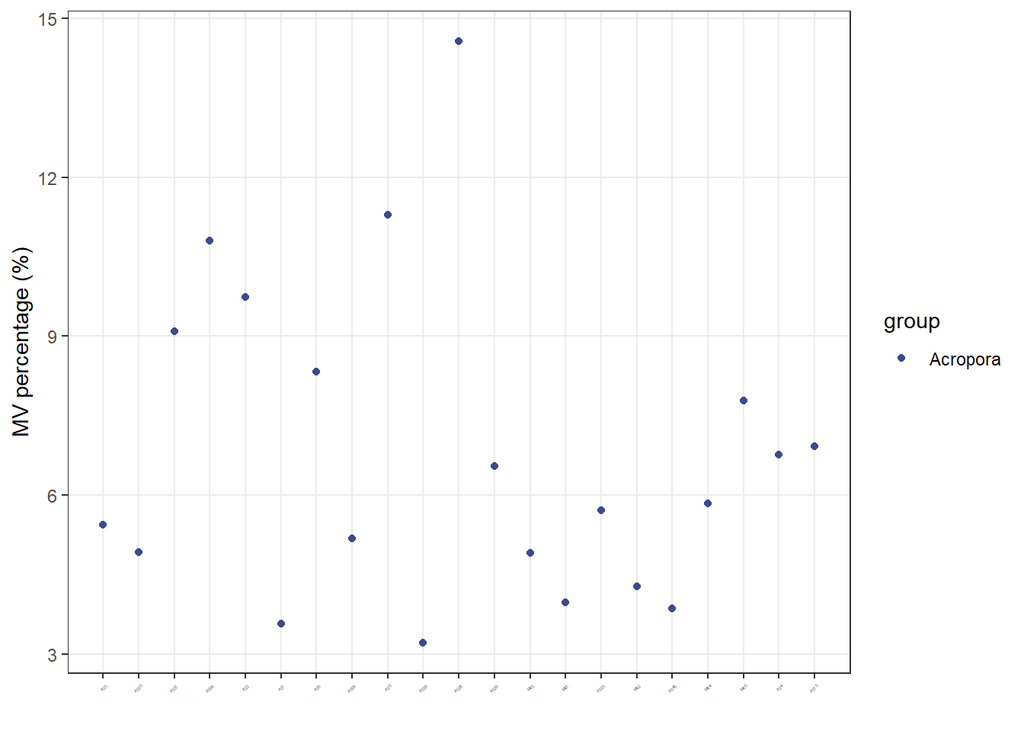

```r
massdataset::show_sample_missing_values(object = object_pos,
                                        color_by = "group",
                                        order_by = "injection.order",
                                        percentage = TRUE) +
  theme(axis.text.x = element_text(size = 2)) +
  scale_size_continuous(range = c(0.1, 2)) +
  ggsci::scale_color_aaas()
```

Negative

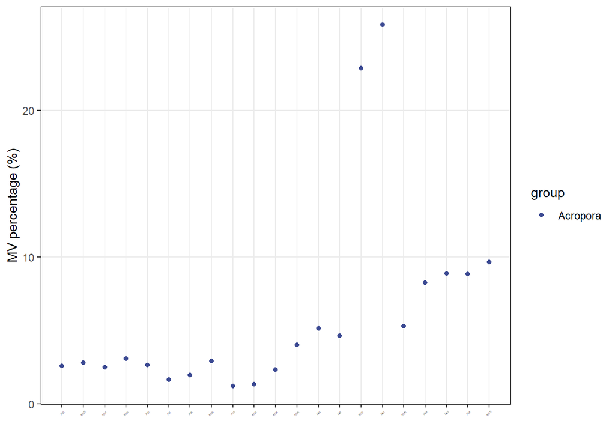

```r
massdataset::show_sample_missing_values(object = object_neg,
                                        color_by = "group",
                                        order_by = "injection.order",
                                        percentage = TRUE) +
  theme(axis.text.x = element_text(size = 2)) +
  scale_size_continuous(range = c(0.1, 2)) +
  ggsci::scale_color_aaas()
```

Detect outliers in samples

Positive

```r
outlier_samples_pos =
  object_pos %>%
  `+`(1) %>%
  log(2) %>%
  scale() %>%
  detect_outlier(); outlier_samples_pos
```

```
## --------------------
## masscleaner
## --------------------
## 1 according_to_na : 0 outlier samples.
## 2 according_to_pc_sd : 0 outlier samples.
## 3 according_to_pc_mad : 0 outlier samples.
## 4 accordint_to_distance : 5 outlier samples.
## A22,A25,A26,A306,A328 .
## extract all outlier table using extract_outlier_table()
```

```r
outlier_table_pos <- extract_outlier_table(outlier_samples_pos) %>%
  apply(1, function(x){
    sum(x)
  }) %>%
  `>`(1) %>%
  which()
outlier_table_pos
```

```
## named integer(0)
```

No positive outliers detected. (need to be identified in 2/4 of the tidymass tests)

Negative

```r
outlier_samples_neg =
  object_neg %>%
  `+`(1) %>%
  log(2) %>%
  scale() %>%
  detect_outlier(); outlier_samples_neg
```

```
## --------------------
## masscleaner
## --------------------
## 1 according_to_na : 0 outlier samples.
## 2 according_to_pc_sd : 0 outlier samples.
## 3 according_to_pc_mad : 0 outlier samples.
## 4 accordint_to_distance : 3 outlier samples.
## A323,M62,M64 .
## extract all outlier table using extract_outlier_table()
```

```r
outlier_table_neg <- extract_outlier_table(outlier_samples_neg) %>%
  apply(1, function(x){
    sum(x)
  }) %>%
  `>`(1) %>%
  which()
outlier_table_neg
```

```
## named integer(0)
```

No negative outliers detected. (need to be identified in 2/4 of the tidymass tests)

Outlier removal

If outliers were detected in *either* ionization mode, they should be removed from *both* so as not to skew the results.

Outliers are removed if they meet the requirements of 2/4 of the masscleaner tests (according_to_na, according_to_pc_sd, according_to_pc_mad, accordint_to_distance)

Combine all outliers into one list.

```r
outlier_table_all <- c(outlier_table_pos, outlier_table_neg)
```

Remove from Positive Dataset

```r
nrow(extract_sample_info(object_pos)) #number of samples before
```

```
## [1] 21
```

```r
object_pos <- object_pos %>%
  activate_mass_dataset(what = "sample_info") %>%
  filter(!sample_id%in%names(outlier_table_all))

nrow(extract_sample_info(object_pos)) #number of samples after
```

```
## [1] 21
```

Check the results of removing outliers

```r
pos_exp_mat <- extract_expression_data(object_pos)
pos_exp_mat[is.na(pos_exp_mat)] <- 0
pca <- prcomp(t(pos_exp_mat), scale. = F)

percentVar <- pca$sdev^2/sum(pca$sdev^2) #save % variation by PC1 and PC2

pos_pca <- data.frame(extract_sample_info(object_pos), pca$x) #make a dataframe containing all plotting info
```

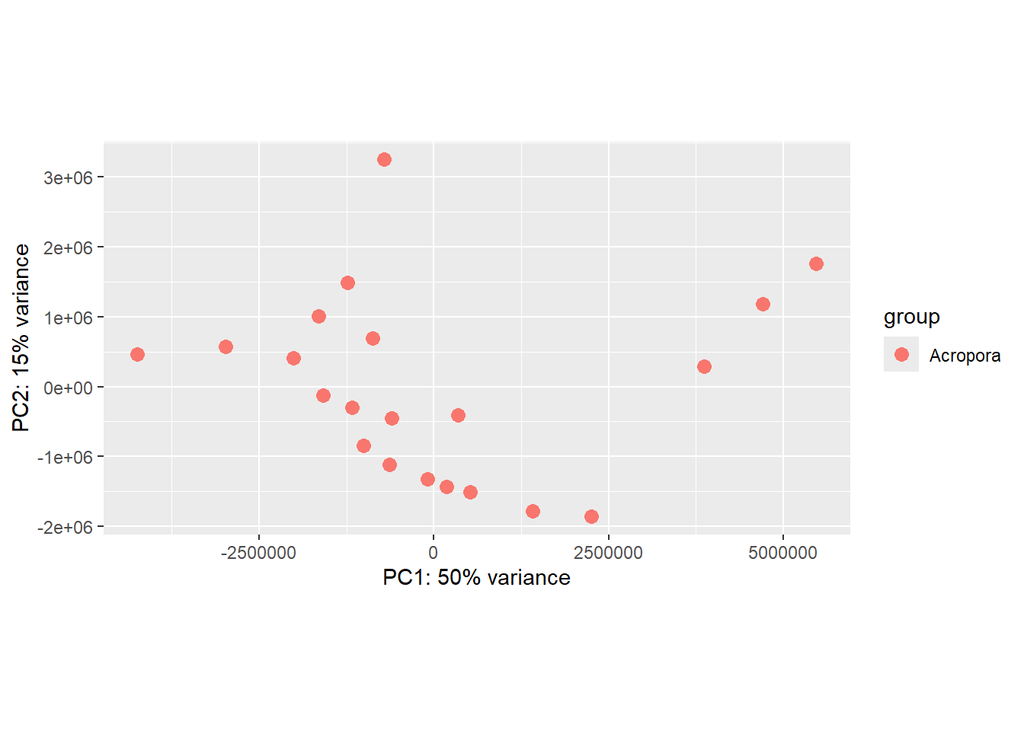

```r
ggplot(data = pos_pca, aes_string(x = "PC1", y = "PC2")) +
  geom_point(size = 3, aes(shape=group, colour=group)) +
  xlab(paste0("PC1: ", round(percentVar[1] * 100), "% variance")) +
  ylab(paste0("PC2: ", round(percentVar[2] * 100), "% variance")) +
  coord_fixed()
```

Remove from Negative Dataset

```r
nrow(extract_sample_info(object_neg)) #number of samples before
```

```
## [1] 21
```

```r
object_neg <- object_neg %>%
  activate_mass_dataset(what = "sample_info") %>%
  filter(!sample_id%in%names(outlier_table_all))

nrow(extract_sample_info(object_neg)) #number of samples after
```

```
## [1] 21
```

Check the results of removing outliers

```r
neg_exp_mat <- extract_expression_data(object_neg)
neg_exp_mat[is.na(neg_exp_mat)] <- 0
pca <- prcomp(t(neg_exp_mat), scale. = F)

percentVar <- pca$sdev^2/sum(pca$sdev^2) #save % variation by PC1 and PC2

neg_pca <- data.frame(extract_sample_info(object_neg), pca$x) #make a dataframe containing all plotting info
```

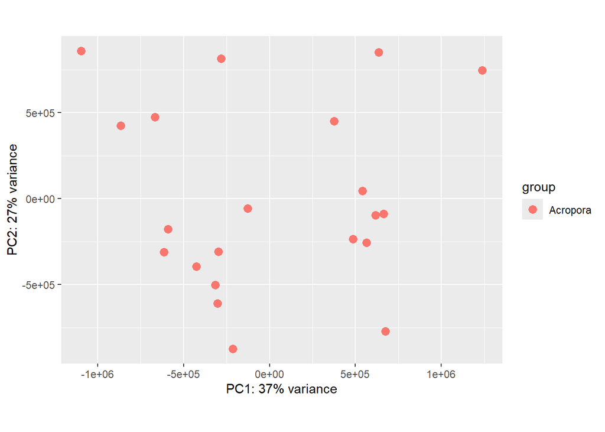

```r
ggplot(data = neg_pca, aes_string(x = "PC1", y = "PC2")) +
  geom_point(size = 3, aes(shape=group, colour=group)) +
  xlab(paste0("PC1: ", round(percentVar[1] * 100), "% variance")) +
  ylab(paste0("PC2: ", round(percentVar[2] * 100), "% variance")) +
  coord_fixed()
```

### MV percentage after filtering, but before imputation

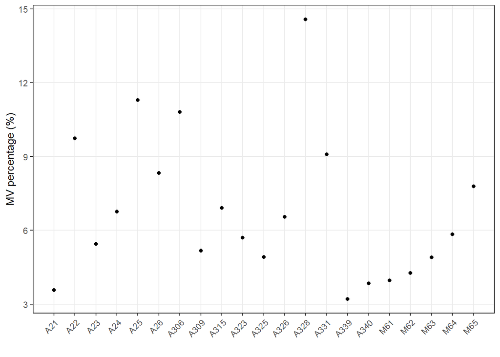

```r
show_sample_missing_values(object = object_pos, percentage = TRUE)
```

```r
MVplot.pos <- show_sample_missing_values(object = object_pos,
                                         percentage = TRUE)
ggsave("3-Metabolomic_workflow/2-Acropora/3-Output/MVplot_pos_before_imputation_acropora.pdf", plot = MVplot.pos, width = 9.1, height = 7, units = "in")
```

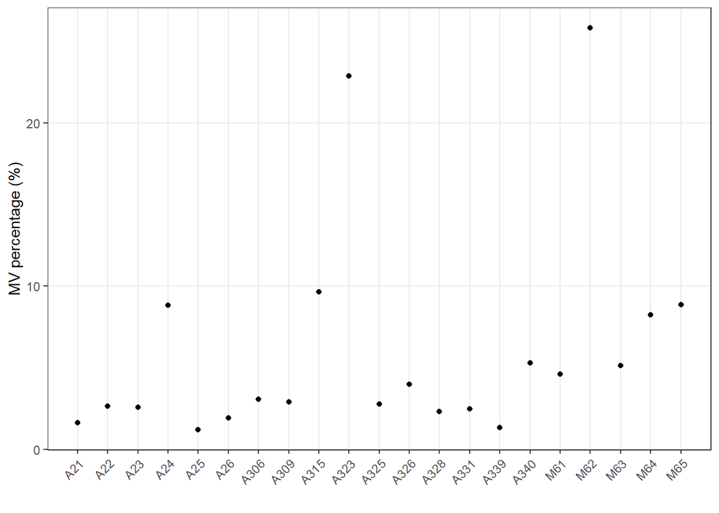

```r
show_sample_missing_values(object = object_neg, percentage = TRUE)
```

```r
MVplot.neg <- show_sample_missing_values(object = object_neg,
                                         percentage = TRUE)
ggsave("3-Metabolomic_workflow/2-Acropora/3-Output/MVplot_neg_before_imputation_acropora.pdf", plot = MVplot.neg, width = 9.1, height = 7, units = "in")
```

### Missing value imputation

Here, we use the random forest method to impute missing values for our two datasets. Sampling methods, such as random forest, have been shown to be the most robust method for imputing missing values in datasets with low structure and with outliers . Knn is a good backup option when you have high structure and low computational power.

#### Positive

```r
get_mv_number(object_pos)
```

```
## [1] 7078
```

```r
object_pos <- impute_mv(object = object_pos, method = "rf")

get_mv_number(object_pos)
```

```
## [1] 0
```

Check data variation

```r
pos_exp_mat <- extract_expression_data(object_pos)
pos_exp_mat[is.na(pos_exp_mat)] <- 0
pca <- prcomp(t(pos_exp_mat), scale. = F)

percentVar <- pca$sdev^2/sum(pca$sdev^2) #save % variation by PC1 and PC2

pos_pca <- data.frame(extract_sample_info(object_pos), pca$x) #make a dataframe containing all plotting info
```

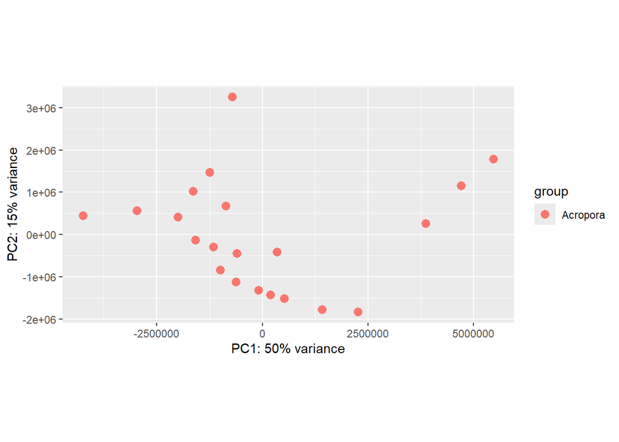

```r
ggplot(data = pos_pca, aes_string(x = "PC1", y = "PC2")) +
  geom_point(size = 3, aes(shape=group, colour=group)) +
  xlab(paste0("PC1: ", round(percentVar[1] * 100), "% variance")) +
  ylab(paste0("PC2: ", round(percentVar[2] * 100), "% variance")) +
  coord_fixed()
```

#### Negative

```r
get_mv_number(object_neg)
```

```
## [1] 3972
```

```r
object_neg <-
  impute_mv(object = object_neg, method = "rf")

get_mv_number(object_neg)
```

```
## [1] 0
```

Check data variation

```r
neg_exp_mat <- extract_expression_data(object_neg)
neg_exp_mat[is.na(neg_exp_mat)] <- 0
pca <- prcomp(t(neg_exp_mat), scale. = F)

percentVar <- pca$sdev^2/sum(pca$sdev^2) #save % variation by PC1 and PC2

neg_pca <- data.frame(extract_sample_info(object_neg), pca$x) #make a dataframe containing all plotting info
```

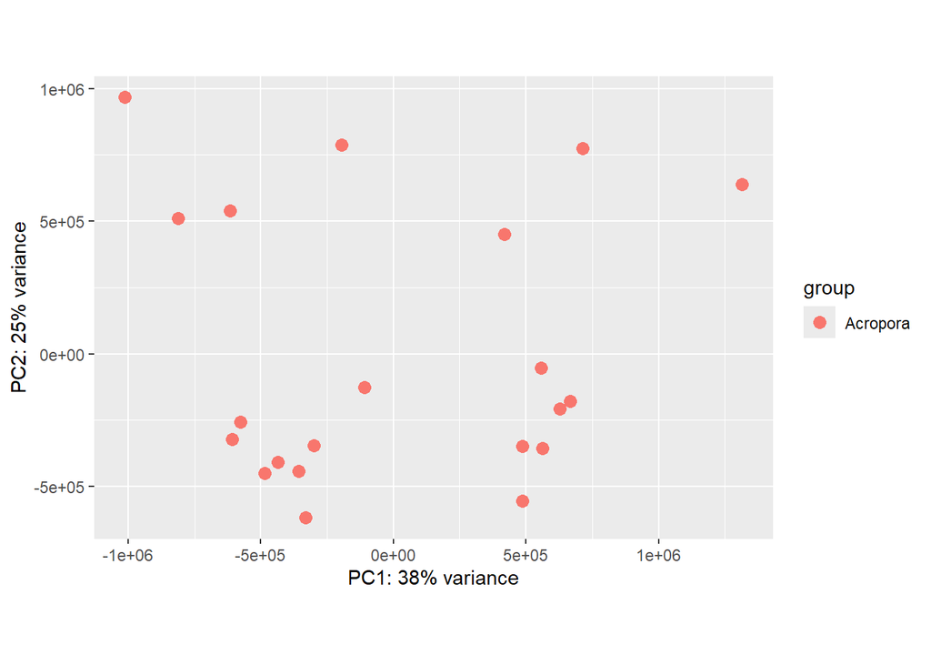

```r
ggplot(data = neg_pca, aes_string(x = "PC1", y = "PC2")) +
  geom_point(size = 3, aes(shape=group, colour=group)) +
  xlab(paste0("PC1: ", round(percentVar[1] * 100), "% variance")) +
  ylab(paste0("PC2: ", round(percentVar[2] * 100), "% variance")) +
  coord_fixed()
```

### Data normalization and integration

Data normalization and integration by the median method. Cannot use QC-based methods like SVR or Loess because we don’t have any QC samples. Play around with the median and mean options and see what works best for your data.

#### Positive

```r
object_pos <-
  normalize_data(object_pos, method = "median")

object_pos2 <-
  integrate_data(object_pos, method = "subject_median")
```

Visualize the normalization method. May have to go back to the last step and try a different method to compare.

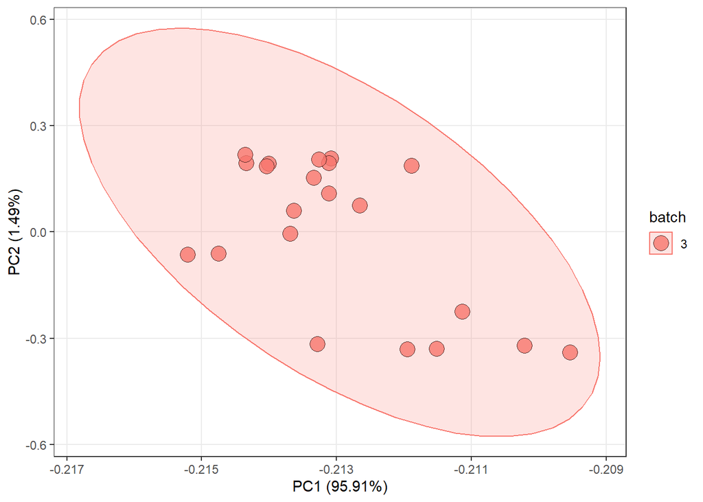

```r
object_pos2 %>%
  `+`(1) %>%
  log(2) %>%
  massqc::massqc_pca(color_by = "batch", line = FALSE)
```

```r
pos_exp_mat <- extract_expression_data(object_pos2)
pos_exp_mat[is.na(pos_exp_mat)] <- 0
pca <- prcomp(t(pos_exp_mat), scale. = F)

percentVar <- pca$sdev^2/sum(pca$sdev^2) #save % variation by PC1 and PC2

pos_pca <- data.frame(extract_sample_info(object_pos2), pca$x) #make a dataframe containing all plotting info
```

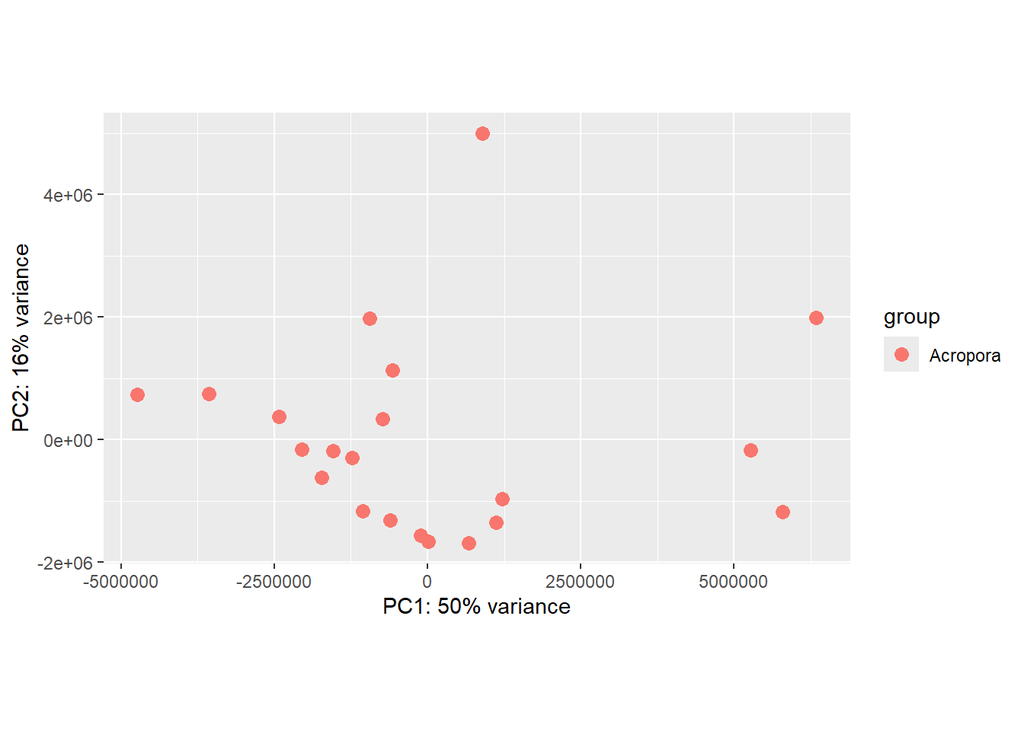

```r
ggplot(data = pos_pca, aes_string(x = "PC1", y = "PC2")) +
  geom_point(size = 3, aes(shape=group, colour=group)) +
  xlab(paste0("PC1: ", round(percentVar[1] * 100), "% variance")) +
  ylab(paste0("PC2: ", round(percentVar[2] * 100), "% variance")) +
  coord_fixed()
```

Plot compound mass-to-charge ratio against retention time

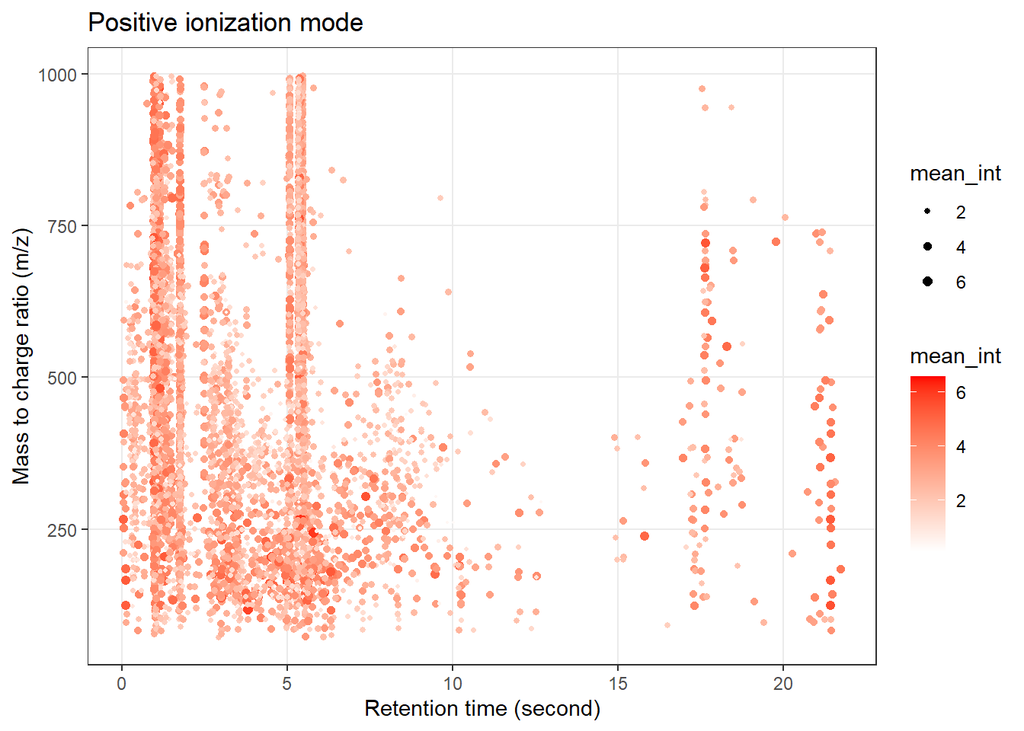

```r
pos_plot <- object_pos2 %>%
  `+`(1) %>%
  log(10) %>%
  show_mz_rt_plot() +
  ggtitle("Positive ionization mode") +
  scale_size_continuous(range = c(0.01, 2)); pos_plot
```

Create a report of raw data quality. Save as HTML.

#### Negative

```r
object_neg <-
  normalize_data(object_neg, method = "median")

object_neg2 <-
  integrate_data(object_neg, method = "subject_median")
```

Visualize the normalization method. May have to go back to the last step and try a different method to compare.

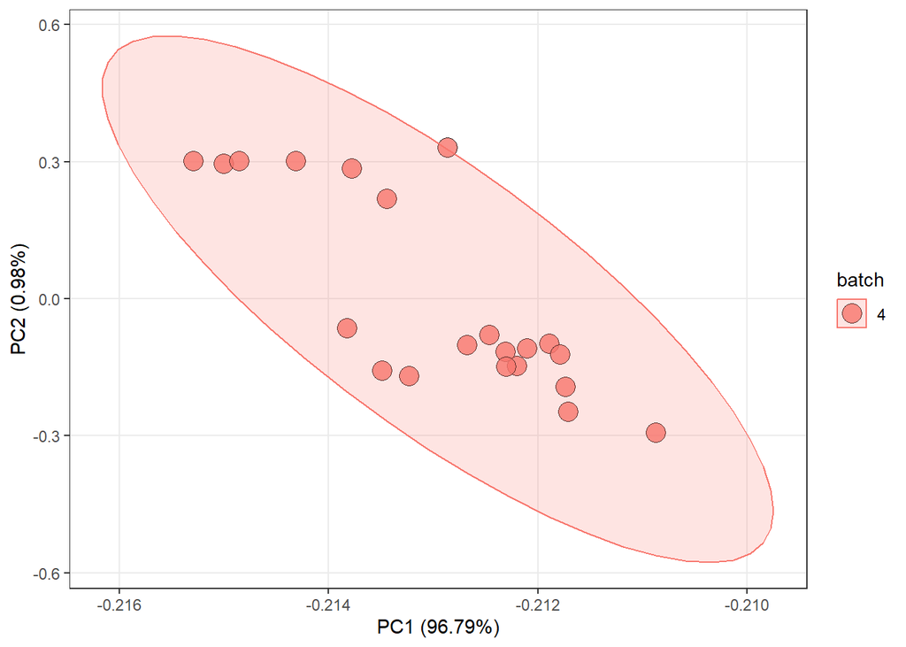

```r
object_neg2 %>%
  `+`(1) %>%
  log(2) %>%
  massqc::massqc_pca(color_by = "batch", line = FALSE)
```

```r
neg_exp_mat <- extract_expression_data(object_neg2)
neg_exp_mat[is.na(neg_exp_mat)] <- 0
pca <- prcomp(t(neg_exp_mat), scale. = F)

percentVar <- pca$sdev^2/sum(pca$sdev^2) #save % variation by PC1 and PC2

neg_pca <- data.frame(extract_sample_info(object_neg2), pca$x) #make a dataframe containing all plotting info
```

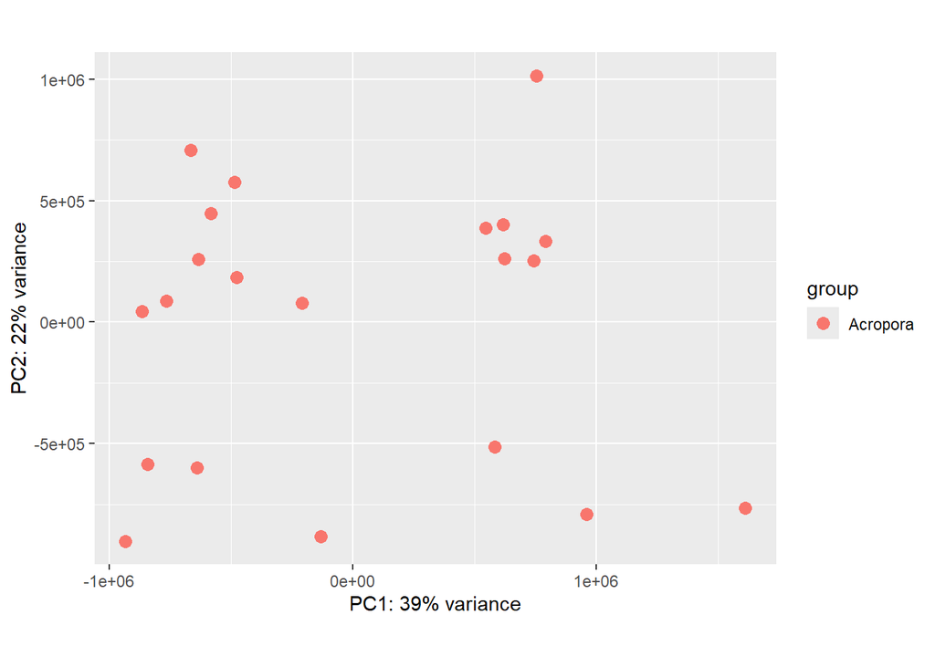

```r
ggplot(data = neg_pca, aes_string(x = "PC1", y = "PC2")) +
  geom_point(size = 3, aes(shape=group, colour=group)) +
  xlab(paste0("PC1: ", round(percentVar[1] * 100), "% variance")) +
  ylab(paste0("PC2: ", round(percentVar[2] * 100), "% variance")) +
  coord_fixed()
```

Plot compound mass-to-charge ratio against retention time

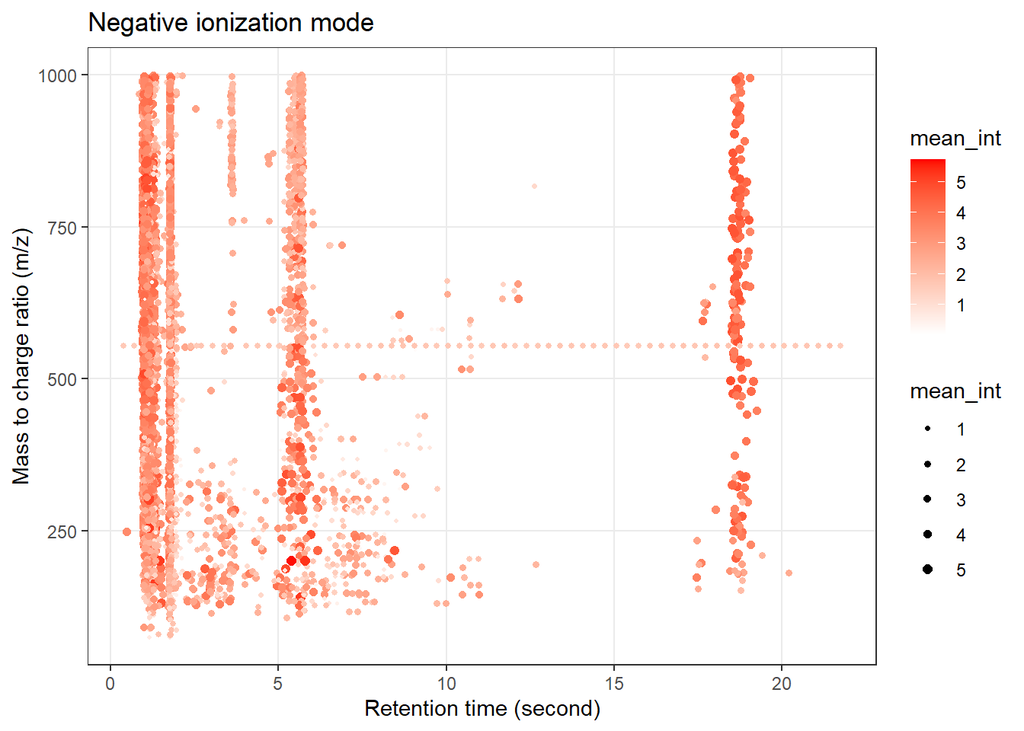

```r
neg_plot <- object_neg2 %>%
  `+`(1) %>%
  log(10) %>%
  show_mz_rt_plot() +
  ggtitle("Negative ionization mode") +
  scale_size_continuous(range = c(0.01, 2)); neg_plot
```

Create a report of raw data quality. Save as HTML.

## Technical variable correction

### Re-load the data

```r
#positive
EDPC <- object_pos2@expression_data
    EDPC <- log(EDPC) %>% t()
MPC <- object_pos2@sample_info
    MPC <- MPC %>% mutate(Ion_mode = "Positive Ionization") %>% mutate(Data_type = "Cleaned Data")
#negative
EDNC <- object_neg2@expression_data
    EDNC <- log(EDNC) %>% t()
MNC <- object_neg2@sample_info
    MNC <- MNC %>% mutate(Ion_mode = "Negative Ionization") %>% mutate(Data_type = "Cleaned Data")
```

### PCA before correction

PCA Function

```r
PCA_loc_ggplot <- function(PC_plot, var_plot, title) {
    ggplot(PC_plot,
    aes(x = PC1, y = PC2, colour = injection.order)) +
    geom_point() +
    ggtitle(paste(title)) +
    xlab(paste0("PC1: ", var_plot$PC1, "% variance")) +
    ylab(paste0("PC2: ", var_plot$PC2, "% variance")) +
    xlim(-120, 120) +
    ylim(-120, 120) +
    theme_bw() + #Set background color
    theme(panel.border = element_blank(), # Set border
        axis.line = element_line(colour = "black", size = 0.6), #Set axes color
        axis.title = element_text(colour = "black", size = 10, face = "bold"), #Axis title size
        plot.background=element_blank(), #Set the plot background
        plot.title = element_text(color="black", size=14, face="bold")
)
}
```

Positive

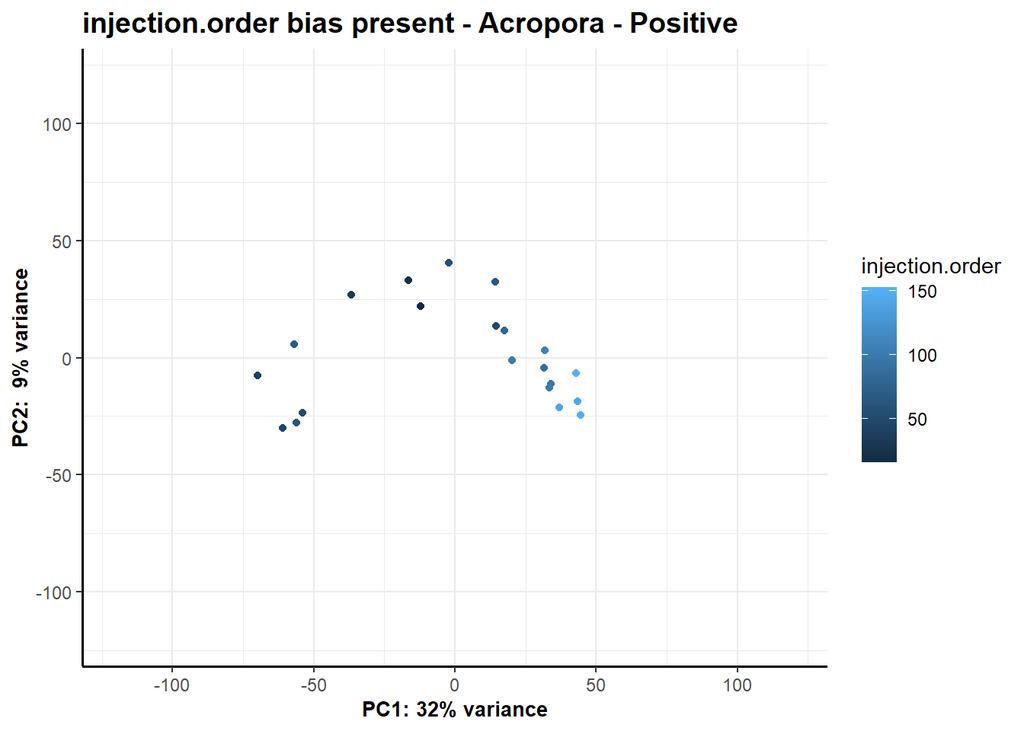

```r
results.EDPC <- prcomp(EDPC, scale = TRUE) #calculate principal components
results.EDPC$rotation <- -1*results.EDPC$rotation #reverse the signs
results.EDPC$x <- -1*results.EDPC$x #reverse the signs of the scores
PC.EDPC <- as.data.frame(results.EDPC$x) #store in a data frame
PC.EDPC.summary <- summary(results.EDPC) #check the proportion of variance
variance.EDPC = (results.EDPC$sdev^2 / sum(results.EDPC$sdev^2))*100 #pull out total variance explained by each principal component
variance.EDPC <- as.data.frame(variance.EDPC) #store variance in a dataframe
variance.EDPC$PCs <- colnames(PC.EDPC)

#reorient and store for ggplots
var_plot.EDPC <- variance.EDPC
var_plot.EDPC$variance.EDPC <- round(var_plot.EDPC$variance.EDPC, digits = 0)
var_plot.EDPC <- as.data.frame(t(var_plot.EDPC))
colnames(var_plot.EDPC) <- var_plot.EDPC[2,]
PC_plot.EDPC <- PC.EDPC
PC_plot.EDPC$sample_id <- rownames(PC_plot.EDPC)

#add qualities to metadata to make easier to plot
PC_plot.EDPC <- full_join(PC_plot.EDPC, MPC, by = "sample_id")

#plot
PCA_plot.EDPC <- PCA_loc_ggplot(PC_plot = PC_plot.EDPC, var_plot = var_plot.EDPC, title = "injection.order bias present - Acropora - Positive"); PCA_plot.EDPC
```

Negative

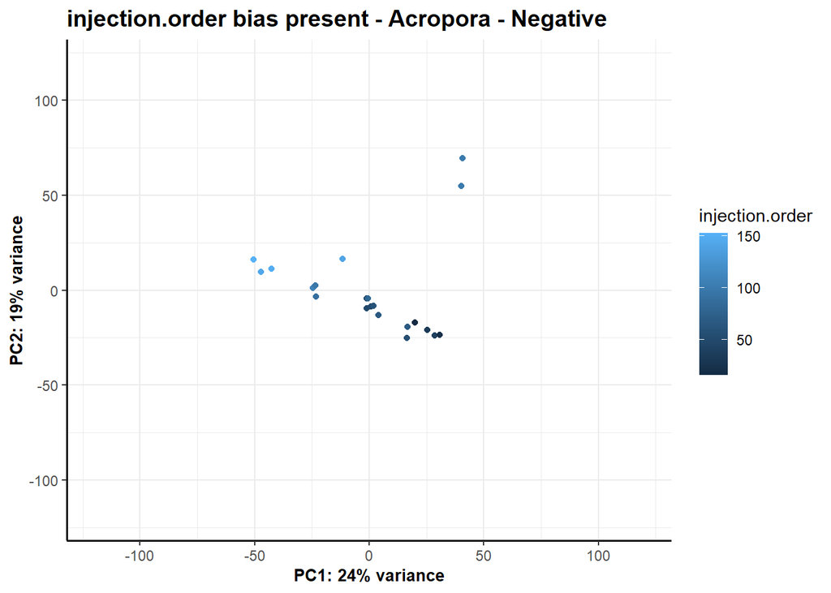

```r
results.EDNC <- prcomp(EDNC, scale = TRUE) #calculate principal components
results.EDNC$rotation <- -1*results.EDNC$rotation #reverse the signs
results.EDNC$x <- -1*results.EDNC$x #reverse the signs of the scores
PC.EDNC <- as.data.frame(results.EDNC$x) #store in a data frame
PC.EDNC.summary <- summary(results.EDNC) #check the proportion of variance
variance.EDNC = (results.EDNC$sdev^2 / sum(results.EDNC$sdev^2))*100 #pull out total variance explained by each principal component
variance.EDNC <- as.data.frame(variance.EDNC) #store variance in a dataframe
variance.EDNC$PCs <- colnames(PC.EDNC)

#reorient and store for ggplots
var_plot.EDNC <- variance.EDNC
var_plot.EDNC$variance.EDNC <- round(var_plot.EDNC$variance.EDNC, digits = 0)
var_plot.EDNC <- as.data.frame(t(var_plot.EDNC))
colnames(var_plot.EDNC) <- var_plot.EDNC[2,]
PC_plot.EDNC <- PC.EDNC
PC_plot.EDNC$sample_id <- rownames(PC_plot.EDNC)

#add qualities to metadata to make easier to plot
PC_plot.EDNC <- full_join(PC_plot.EDNC, MPC, by = "sample_id")

#plot
PCA_plot.EDNC <- PCA_loc_ggplot(PC_plot = PC_plot.EDNC, var_plot = var_plot.EDNC, title = "injection.order bias present - Acropora - Negative"); PCA_plot.EDNC
```

### Get rid of technical bias

Positive

```r
library(limma)
MPC_corr <- MPC %>% dplyr::select(injection.order, sample_id)
row.names(MPC_corr) <- MPC$sample_id

MPC_corr <- MPC_corr[row.names(EDPC),]
MPC_corr <- as.data.frame(lapply(MPC_corr, factor))
MPC_corr <- as.data.frame(lapply(MPC_corr, as.numeric))

design <- model.matrix(~sample_id + injection.order, data = MPC_corr)
sample_id.design <- design[, 1:2]
batch.design <- design[, -(1:2)]
corr.data.pos <- removeBatchEffect(t(EDPC), design = sample_id.design, covariates = batch.design)

EDPC.cln      <- corr.data.pos
EDPC.cln.save <- corr.data.pos
```

Negative

```r
MNC_corr <- MNC %>% dplyr::select(injection.order, sample_id)
row.names(MNC_corr) <- MNC$sample_id

MNC_corr <- MNC_corr[row.names(EDNC),]
MNC_corr <- as.data.frame(lapply(MNC_corr, factor))
MNC_corr <- as.data.frame(lapply(MNC_corr, as.numeric))

design <- model.matrix(~sample_id + injection.order, data = MNC_corr)
sample_id.design <- design[, 1:2]
batch.design <- design[, -(1:2)]
corr.data.neg <- removeBatchEffect(t(EDNC), design = sample_id.design, covariates = batch.design)

EDNC.cln      <- corr.data.neg
EDNC.cln.save <- corr.data.neg
```

## Positive

Re-orient data for PCA

```r
EDPC.cln[EDPC.cln < 0] <- 1
EDPC.cln <- log(EDPC.cln) %>% t()
#remove metabolites w/o variance
sds <- apply(EDPC.cln, 2, sd, na.rm = TRUE) # Check for variance using std deviation
names(sds)[sds == 0] # Print columns that have a standard deviation of 0
```

```
## [1] "5.24_196.1708m/z"
```

```r
EDPC.cln <- EDPC.cln[, apply(EDPC.cln, 2, sd, na.rm = TRUE) > 0] # Keep only columns w/ variance
```

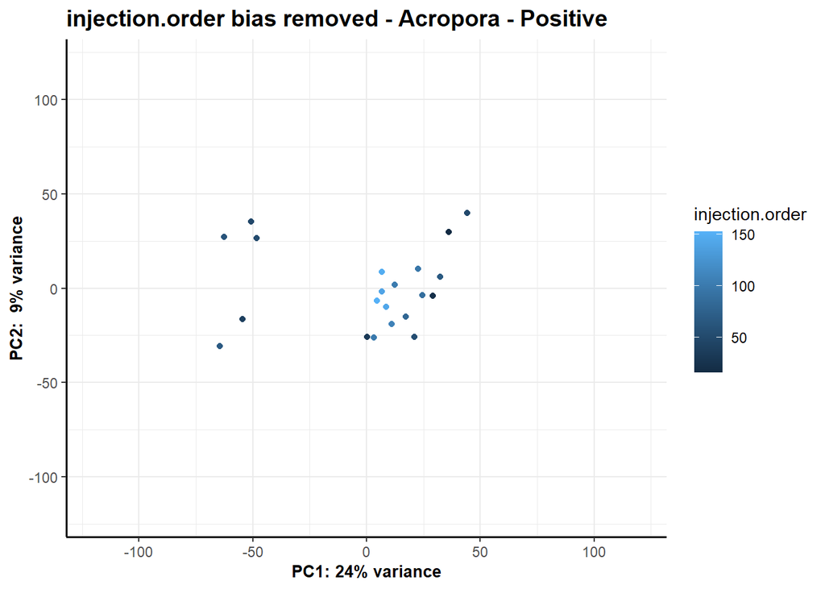

```r
results.EDPC.cln <- prcomp(EDPC.cln, scale = TRUE) #calculate principal components
results.EDPC.cln$rotation <- -1*results.EDPC.cln$rotation #reverse the signs
results.EDPC.cln$x <- -1*results.EDPC.cln$x #reverse the signs of the scores
PC.EDPC.cln <- as.data.frame(results.EDPC.cln$x) #store in a data frame
PC.EDPC.cln.summary <- summary(results.EDPC.cln) #check the proportion of variance
variance.EDPC.cln = (results.EDPC.cln$sdev^2 / sum(results.EDPC.cln$sdev^2))*100 #pull out total variance explained by each principal component
variance.EDPC.cln <- as.data.frame(variance.EDPC.cln) #store variance in a dataframe
variance.EDPC.cln$PCs <- colnames(PC.EDPC.cln)

#reorient and store for ggplots
var_plot.EDPC.cln <- variance.EDPC.cln
var_plot.EDPC.cln$variance.EDPC.cln <- round(var_plot.EDPC.cln$variance.EDPC.cln, digits = 0)
var_plot.EDPC.cln <- as.data.frame(t(var_plot.EDPC.cln))
colnames(var_plot.EDPC.cln) <- var_plot.EDPC.cln[2,]
PC_plot.EDPC.cln <- PC.EDPC.cln
PC_plot.EDPC.cln$sample_id <- rownames(PC_plot.EDPC.cln)

#add qualities to metadata to make easier to plot
PC_plot.EDPC.cln <- full_join(PC_plot.EDPC.cln, MPC, by = "sample_id")

#plot
PCA_plot.EDPC.cln <- PCA_loc_ggplot(PC_plot = PC_plot.EDPC.cln, var_plot = var_plot.EDPC.cln, title = "injection.order bias removed - Acropora - Positive"); PCA_plot.EDPC.cln
```

PCA indicates no additional samples should be removed.

## Negative

Re-orient data for PCA

```r
EDNC.cln[EDNC.cln < 0] <- 1
EDNC.cln <- log(EDNC.cln) %>% t()
#remove metabolites w/o variance
sds <- apply(EDNC.cln, 2, sd, na.rm = TRUE) # Check for variance using std deviation
names(sds)[sds == 0] # Print columns that have a standard deviation of 0
```

```
## [1] "1.04_289.9353m/z" "1.03_792.9175m/z" "1.03_784.9172m/z"
```

```r
EDNC.cln <- EDNC.cln[, apply(EDNC.cln, 2, sd, na.rm = TRUE) > 0] # Keep only columns w/ variance
```

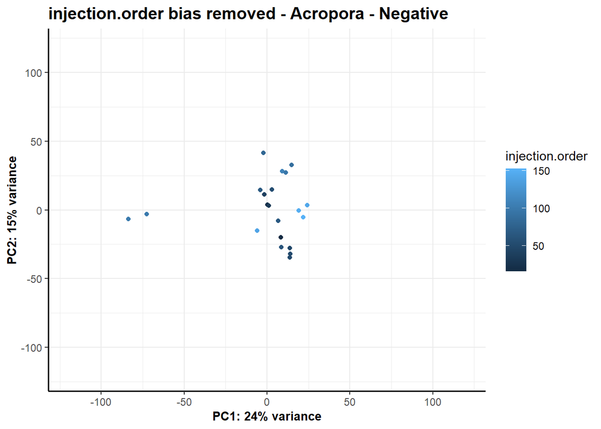

```r
results.EDNC.cln <- prcomp(EDNC.cln, scale = TRUE) #calculate principal components
results.EDNC.cln$rotation <- -1*results.EDNC.cln$rotation #reverse the signs
results.EDNC.cln$x <- -1*results.EDNC.cln$x #reverse the signs of the scores
PC.EDNC.cln <- as.data.frame(results.EDNC.cln$x) #store in a data frame
PC.EDNC.cln.summary <- summary(results.EDNC.cln) #check the proportion of variance
variance.EDNC.cln = (results.EDNC.cln$sdev^2 / sum(results.EDNC.cln$sdev^2))*100 #pull out total variance explained by each principal component
variance.EDNC.cln <- as.data.frame(variance.EDNC.cln) #store variance in a dataframe
variance.EDNC.cln$PCs <- colnames(PC.EDNC.cln)

#reorient and store for ggplots
var_plot.EDNC.cln <- variance.EDNC.cln
var_plot.EDNC.cln$variance.EDNC.cln <- round(var_plot.EDNC.cln$variance.EDNC.cln, digits = 0)
var_plot.EDNC.cln <- as.data.frame(t(var_plot.EDNC.cln))
colnames(var_plot.EDNC.cln) <- var_plot.EDNC.cln[2,]
PC_plot.EDNC.cln <- PC.EDNC.cln
PC_plot.EDNC.cln$sample_id <- rownames(PC_plot.EDNC.cln)

#add qualities to metadata to make easier to plot
PC_plot.EDNC.cln <- full_join(PC_plot.EDNC.cln, MPC, by = "sample_id")

#plot
PCA_plot.EDNC.cln <- PCA_loc_ggplot(PC_plot = PC_plot.EDNC.cln, var_plot = var_plot.EDNC.cln, title = "injection.order bias removed - Acropora - Negative"); PCA_plot.EDNC.cln
```

PCA indicates two additional outlier samples should be removed.

Identify outliers in the PCA

```r
library(dplyr)
PC1_mean <- mean(abs(PC_plot.EDNC.cln$PC1))
PC1_stdv <- sd(abs(PC_plot.EDNC.cln$PC1))

high <- abs(PC1_mean + (2*PC1_stdv))

PCA.outliers <- PC_plot.EDNC.cln %>%
  dplyr::filter(abs(PC1) > high)
PCA.outliers <- PCA.outliers$sample_id
```

M62 and A323 identified as outliers.

Remove from negative and positive

```r
EDNC.cln.save <- EDNC.cln.save[, !colnames(EDNC.cln.save) %in% PCA.outliers]
EDPC.cln.save <- EDPC.cln.save[, !colnames(EDPC.cln.save) %in% PCA.outliers]
```

Redo the final PCAs

## Positive

Re-orient data for PCA

```r
EDPC.cln <- EDPC.cln.save
EDPC.cln[EDPC.cln < 0] <- 1
EDPC.cln <- log(EDPC.cln) %>% t()
#remove metabolites w/o variance
sds <- apply(EDPC.cln, 2, sd, na.rm = TRUE) # Check for variance using std deviation
names(sds)[sds == 0] # Print columns that have a standard deviation of 0
```

```
## [1] "5.24_196.1708m/z"
```

```r
EDPC.cln <- EDPC.cln[, apply(EDPC.cln, 2, sd, na.rm = TRUE) > 0] # Keep only columns w/ variance
```

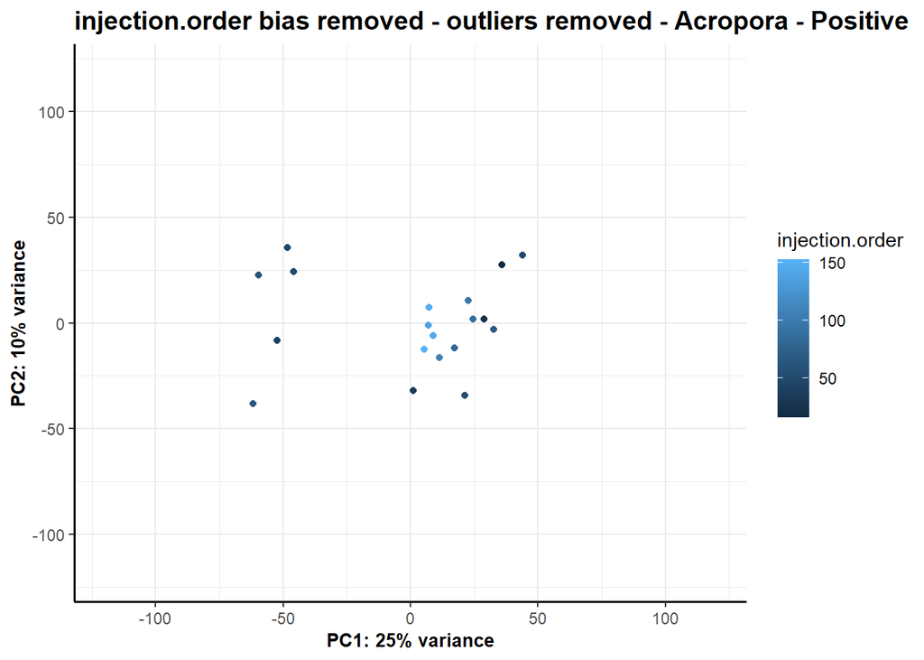

```r
results.EDPC.cln <- prcomp(EDPC.cln, scale = TRUE) #calculate principal components
results.EDPC.cln$rotation <- -1*results.EDPC.cln$rotation #reverse the signs
results.EDPC.cln$x <- -1*results.EDPC.cln$x #reverse the signs of the scores
PC.EDPC.cln <- as.data.frame(results.EDPC.cln$x) #store in a data frame
PC.EDPC.cln.summary <- summary(results.EDPC.cln) #check the proportion of variance
variance.EDPC.cln = (results.EDPC.cln$sdev^2 / sum(results.EDPC.cln$sdev^2))*100 #pull out total variance explained by each principal component
variance.EDPC.cln <- as.data.frame(variance.EDPC.cln) #store variance in a dataframe
variance.EDPC.cln$PCs <- colnames(PC.EDPC.cln)

#reorient and store for ggplots
var_plot.EDPC.cln <- variance.EDPC.cln
var_plot.EDPC.cln$variance.EDPC.cln <- round(var_plot.EDPC.cln$variance.EDPC.cln, digits = 0)
var_plot.EDPC.cln <- as.data.frame(t(var_plot.EDPC.cln))
colnames(var_plot.EDPC.cln) <- var_plot.EDPC.cln[2,]
PC_plot.EDPC.cln <- PC.EDPC.cln
PC_plot.EDPC.cln$sample_id <- rownames(PC_plot.EDPC.cln)

#add qualities to metadata to make easier to plot
PC_plot.EDPC.cln <- full_join(PC_plot.EDPC.cln, MPC, by = "sample_id")

#plot
PCA_plot.EDPC.cln <- PCA_loc_ggplot(PC_plot = PC_plot.EDPC.cln, var_plot = var_plot.EDPC.cln, title =  "injection.order bias removed - outliers removed - Acropora - Positive"); PCA_plot.EDPC.cln
```